# Práctica dirigida 12

[figure not shown]

Cargamos la base de datos:

```r
library(rio)
data=import("LCV1819-1.sav")
```

# CHI CUADRADO Y PRUEBAS DE ASOCIACIÓN

Recordemos que chi cuadrado es una prueba para probar si existe asociación entre variables categóricas.

H0: Las variables son estadísticamente independientes/no hay dependencia H1: Las variables son estadísticamente dependientes.

OJO: Recuerden que hablar de asociación no implica causalidad.

## Ejercicio 1:

Queremos saber si existe asociación entre el gasto en el trasporte agrupado y otras variables, en específico, queremos saber si

¿Existe asociación entre el gasto en transporte agrupado y la edad agrupada (EDAD)?

La variable gasto en trasporte (PEA10A) es numérica. Ante ello, tenemos que separar esta variable en 3 grupos, nos guiaremos de los cuartiles para crear los grupos: Bajo(menos de 20) , medio (de 20 a 70) , Alto (más de 70). La nueva variable se llamará “GASTO_T”.

```r
summary(data$PE10A)
```

```
##     Min.  1st Qu.   Median     Mean  3rd Qu.     Max.     NA's
##     0.00    10.00    20.00    81.33    70.00 14000.00      304
```

```r
library(tidyverse)
data = data %>%
  mutate(GASTO_T=case_when(PE10A<20 ~ "1.BAJO",
                             PE10A>=20 & EG2OTRO<=70 ~ "2.MEDIO",
                             PE10A>70 ~ "3.ALTO"))

data$GASTO_T= factor(data$GASTO_T)
```

```r
data$EDAD=factor(data$EDAD, levels = c(1:3),labels = c("18 a 29",
                                                        "30 a 44",
                                                         "más de 45"))
```

Creemos nuestra tabla de contingencia

```r
tabla=table(data$GASTO_T,data$EDAD)
tabla #con esta realizamos la prueba
```

```
##
##           18 a 29 30 a 44 más de 45
##   1.BAJO      383     441       483
##   2.MEDIO     195     274       427
##   3.ALTO      190     159       121
```

En porcentajes: calculamos el 100% sobre “EDAD”

```r
tabla_p= tabla %>%
  prop.table(2)%>% #porcentaje por columna
  round(2)*100
tabla_p
```

```
##
##           18 a 29 30 a 44 más de 45
##   1.BAJO       50      50        47
##   2.MEDIO      25      31        41
##   3.ALTO       25      18        12
```

Grafiquemos:

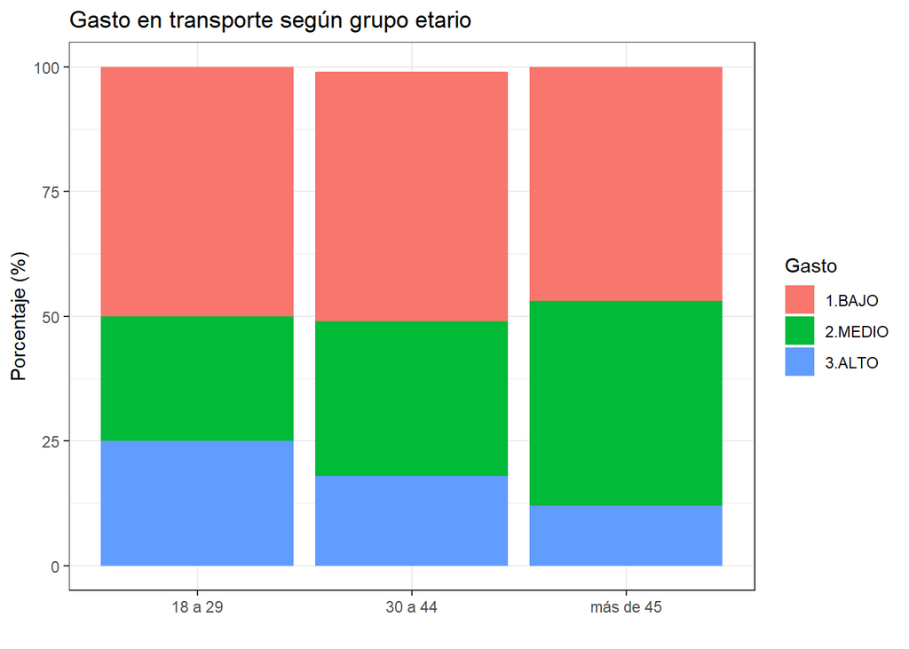

```r
toPlot = as.data.frame(tabla_p)
names(toPlot) = c("Gasto", "Edad", "Porcentaje")

ggplot(toPlot, aes(fill=Gasto, y=Porcentaje, x=Edad)) +
    geom_bar(stat="identity") +
    labs( y = 'Porcentaje (%)', x = ' ')+
    ggtitle('Gasto en transporte según grupo etario')+
    theme_bw()
```

```r
chisq.test(tabla)$expected
```

```
##
##            18 a 29  30 a 44 más de 45
##   1.BAJO  375.5241 427.3543  504.1216
##   2.MEDIO 257.4366 292.9682  345.5952
##   3.ALTO  135.0393 153.6775  181.2832
```

Podemos proceder con la prueba

```r
chisq.test(tabla)
```

```
##
##  Pearson's Chi-squared test
##
## data:  tabla
## X-squared = 79.615, df = 4, p-value < 2.2e-16
```

De acuerdo al p–value obtenido en la prueba de hipótesis de Chi2, al ser menor de 0.05, podemos rechazar la hipótesis nula. Por lo tanto, concluimos que existe dependencia entre el gasto en transporte (bajo/medio/alto) y el grupo etario.

## Ejercicio 2:

Queremos saber si existe asociación entre el gasto en transporte agrupado y el sexo (SEXO)

```r
data$SEXO_F=factor(data$SEXO, levels = c(1:2),labels = c("Hombre","Mujer"))
```

Creemos nuestra tabla de contingencia

```r
tabla=table(data$GASTO_T,data$SEXO_F)
tabla #con esta realizamos la prueba
```

```
##
##           Hombre Mujer
##   1.BAJO     639   668
##   2.MEDIO    416   480
##   3.ALTO     224   246
```

En porcentajes: calculamos el 100% sobre “SEXO”

```r
tabla_p= tabla %>%
  prop.table(2)%>% #porcentaje por columna
  round(2)*100
tabla_p
```

```
##
##           Hombre Mujer
##   1.BAJO      50    48
##   2.MEDIO     33    34
##   3.ALTO      18    18
```

Grafiquemos:

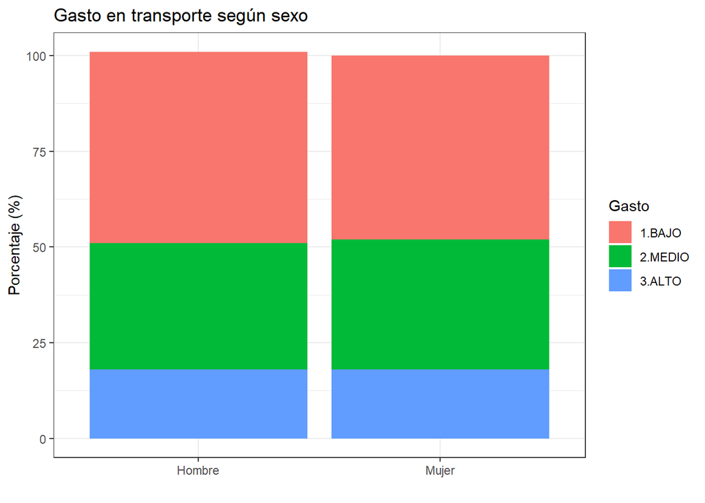

```r
toPlot = as.data.frame(tabla_p)
names(toPlot) = c("Gasto", "Sexo", "Porcentaje")

ggplot(toPlot, aes(fill=Gasto, y=Porcentaje, x=Sexo)) +
    geom_bar(stat="identity") +
    labs( y = 'Porcentaje (%)', x = ' ')+
    ggtitle('Gasto en transporte según sexo')+
    theme_bw()
```

¿Qué hallazgos podría comentar respecto a la visualización?

```r
chisq.test(tabla)$expected
```

```
##
##             Hombre    Mujer
##   1.BAJO  625.3846 681.6154
##   2.MEDIO 428.7258 467.2742
##   3.ALTO  224.8896 245.1104
```

Podemos proceder con la prueba

```r
chisq.test(tabla)
```

```
##
##  Pearson's Chi-squared test
##
## data:  tabla
## X-squared = 1.2995, df = 2, p-value = 0.5222
```

De acuerdo al p–value obtenido en la prueba de hipótesis de Chi2, al ser mayor de 0.05, podemos aceptar la hipótesis nula. Por lo tanto, concluimos que no existe dependencia entre el gasto en transporte (bajo/medio/alto) y el sexo.

## Ejercicio 3:

Queremos saber si existe asociación entre el gasto en transporte agrupado y el nivel socioeconómico (NSE_IOP). Grafica, realiza la prueba estadística correspondiente y comenta los resultados.

## Ejercicio 4:

Queremos saber si existe asociación entre el gasto en transporte agrupado y el estrato geográfico (ESTRATOS_IOP) Grafica, realiza la prueba estadística correspondiente y comenta los resultados.

## Ejercicio 5:

# CORRELACIÓN

Esta es una medida de relación entre dos variables cuantitativas o numéricas.

H0 = No existe correlación las variables H1 = Sí existe correlación entre las variables

En esta prueba, no es suficiente analizar el pvalue, también debemos interpretar el coeficiente de correlación de pearson. Este nos indica la fuerza y la dirección de la relación entre las variables.

## Ejercicio 6:

Ahora queremos explorar si existe relación entre el gasto en educación (PE10D) y la edad (ANIOS)

```r
str(data$PE10D)
```

```
##  num [1:3744] 100 300 150 400 0 0 0 0 250 50 ...
##  - attr(*, "label")= chr "En promedio, cuánto gasta su hogar en Educación (pensiones, útiles, matrícula) (monto)"
##  - attr(*, "format.spss")= chr "F8.2"
```

Previo a la prueba, realicemos un gráfico de dispersión para hacernos una idea inicial

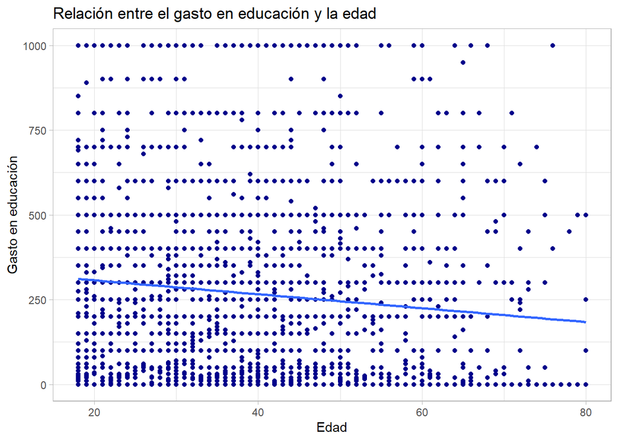

```r
ggplot(data,aes(x=ANIOS, y=data$PE10D)) +
  geom_point(colour="darkblue") +  xlab("Edad") +  ylab("Gasto en educación") +
  ggtitle("Relación entre el gasto en educación y la edad") +
  xlim(18,80)+ylim(0,1000)+
  theme_light() +
  geom_smooth(method="lm", se = F)
```

Podemos ver bastante dispersión, no parece haber correlación entre las variables.

```r
cor.test(data$ANIOS,data$PE10D)
```

```
##
##  Pearson's product-moment correlation
##
## data:  data$ANIOS and data$PE10D
## t = -3.2686, df = 2664, p-value = 0.001094
## alternative hypothesis: true correlation is not equal to 0
## 95 percent confidence interval:
##  -0.10092230 -0.02530033
## sample estimates:
##         cor
## -0.06320204
```

Siendo el p-valor menor a 0.05, podemos rechazar la hipótesis nula y concluir que existe relación entre la edad y el gasto en educación. Adicionalmente, podemos determinar que esta relación es inversa y no relevante (r = 0.06).

## Ejercicio 7:

Ahora queremos explorar si existe relación entre el gasto en salud (PE10E) y la edad (ANIOS)

## Ejercicio 8:

Ahora queremos explorar si existe relación entre el gasto en salud (PE10E) y la evaluación de la gestión de la Municipalidad de Lima Metropolitana (GP7)

## Ejercicio 9:

Ahora queremos explorar si existe relación entre el gasto en alimentación (PE10B) y la edad (ANIOS)

# REGRESIÓN SIMPLE

Recordemos que con la regresión predecimos el valor de una variable con los valores de otra. La regresión lineal simple es un método útil para predecir una respuesta cuantitativa Y partiendo de una sola variable predictora X, asumiendo que hay una relación aproximadamente lineal entre X e Y.

## Pasos para la regresión lineal simple

- Paso 1: Analizar la asociación entre las variables de insumo: Diagrama de dispersión y correlación bivariada, en caso de variables numéricas
- Paso 2: Conocer qué tanto explica el modelo: COEFICIENTE DE DETERMINACIÓN – R2
- Paso 3: Conocer los parámetros del modelo: TABLA DE COEFICIENTES
- Paso 4: Construir la ecuación y predecir

## Ejercicio 10:

Queremos analizar posibles modelos que expliquen la percepción de los limeños acerca del transporte público informal (buses, cousters y combis, y mototaxis). Para esto calcularemos un indice aditivo de la calificación de los servicios de buses (MT7A), de cousters y combis (MT7B) y de mototaxis (MT7D), que varíe de 0 a 100.

Creación del índice:

```r
data$evaluacion_ti = ((data$MT7A + data$MT7B + data$MT7D)-3)/12*100
summary(data$evaluacion_ti)
```

```
##    Min. 1st Qu.  Median    Mean 3rd Qu.    Max.    NA's
##    0.00   33.33   50.00   47.95   58.33  100.00    1626
```

Paso 1: Diagrama de dispersión y correlación bivariada

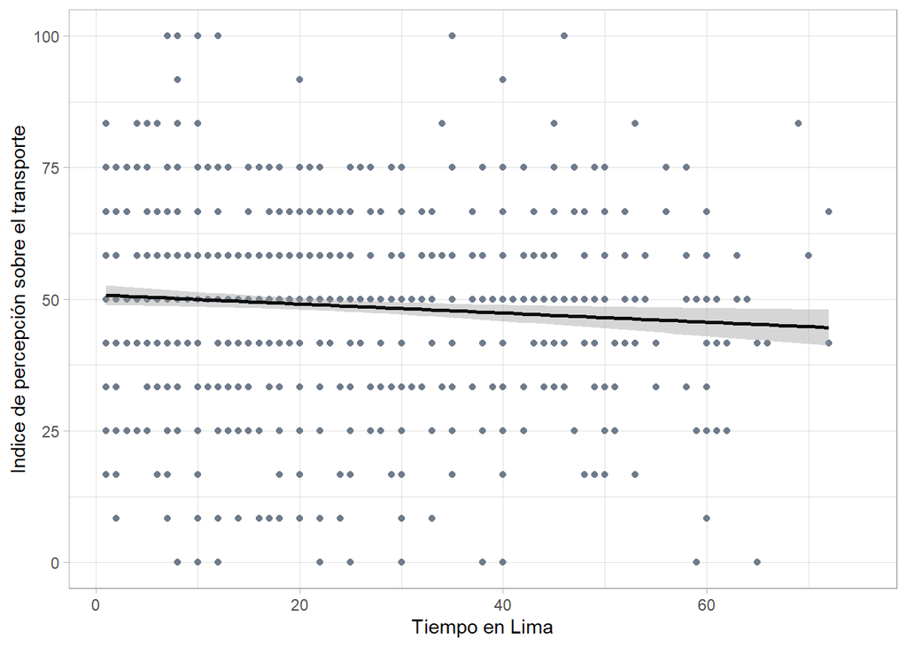

```r
library(ggplot2)
ggplot(data, aes(x=EG2OTRO, y=evaluacion_ti)) +
  geom_point(colour="lightsteelblue4") +
  xlab("Tiempo en Lima") +
  ylab("Indice de percepción sobre el transporte")+ theme_light() +
  geom_smooth(method="lm", se = T, colour="grey5")
```

Correlación:

```r
cor.test(data$evaluacion_ti, data$EG2OTRO)
```

```
##
##  Pearson's product-moment correlation
##
## data:  data$evaluacion_ti and data$EG2OTRO
## t = -2.5253, df = 975, p-value = 0.01172
## alternative hypothesis: true correlation is not equal to 0
## 95 percent confidence interval:
##  -0.14260835 -0.01798253
## sample estimates:
##         cor
## -0.08061048
```

Podemos observar que existe correlación entre ambas variables (p valor = 0,012) y que la correlación es negativa y que no es relevante (r = -0.08).

```r
modelo1 = lm(data$evaluacion_ti ~ data$EG2OTRO)
summary(modelo1)
```

```
##
## Call:
## lm(formula = data$evaluacion_ti ~ data$EG2OTRO)
##
## Residuals:
##     Min      1Q  Median      3Q     Max
## -50.153  -8.572   1.053   9.645  53.120
##
## Coefficients:
##              Estimate Std. Error t value Pr(>|t|)
## (Intercept)  50.84202    0.98083  51.836   <2e-16 ***
## data$EG2OTRO -0.08614    0.03411  -2.525   0.0117 *
## ---
## Signif. codes:  0 '***' 0.001 '**' 0.01 '*' 0.05 '.' 0.1 ' ' 1
##
## Residual standard error: 17.15 on 975 degrees of freedom
##   (2767 observations deleted due to missingness)
## Multiple R-squared:  0.006498,   Adjusted R-squared:  0.005479
## F-statistic: 6.377 on 1 and 975 DF,  p-value: 0.01172
```

Ahora, debemos responder las siguientes preguntas:

- ¿Qué tanto explica el modelo?

Con un valor de 0,006, podemos afirmar que el **0,6%** de la variabilidad del índice aditivo de la calificación del transporte es explicada por el tiempo que una persona vive en Lima.

- ¿La variable aporta al modelo?

H0: La variable X no tiene un efecto estadísticamente significativo en la variable Y. H1: La variable X tiene un efecto estadísticamente significativo en la variable Y.

Con un **p valor < 0,05** podemos afirmar que la variable “tiempo que una persona vive en Lima” aporta al modelo de regresión.

```r
modelo1$coefficients
```

```
##  (Intercept) data$EG2OTRO
##  50.84201594  -0.08613805
```

**Y = 50.84202 - 0.0861(EG2OTRO)**

## Ejercicio 11:

Realizar el ejercicio con otra variable explicativa: Gasto en transporte (PE10A)

# REGRESIÓN MÚLTIPLE

De manera independiente, vemos que cada modelo explica de manera diferente nuestra variable de interés, ahora probemos combinando algunas de estas variables y busquemos alguna diferencia en el porcentaje de predicción.

## Ejercicio 12:

VD = Evaluación del transporte informal (evaluacion_ti) VI = Gasto de su hogar en transporte (PE10A) + Tiempo que vive en la ciudad de Lima (EG2OTRO)+ sexo del encuestado (Hombre = 1; Mujer = “2”)

```r
# La variable sexo se puede tratar de 2 maneras.
# Primer caso: convertir a factor y tener un categoría de referencia. Para el ejemplo nos referiremos a MUJER.

data <- data %>%
  mutate(SEXO_FACTOR = case_when(
    SEXO == 1 ~ 0,
    SEXO == 2 ~ 1),
    SEXO_FACTOR = as.factor(SEXO_FACTOR))

# Segundo caso: usar fastdummies
library(fastDummies)
data = dummy_cols(data,  select_columns = c("SEXO"))
data = data %>% rename(SEXO_HOMBRE=SEXO_1, SEXO_MUJER=SEXO_2)
```

```r
modelo2 = lm(data$evaluacion_ti ~ data$EG2OTRO + data$PE10A + data$SEXO_FACTOR)
summary(modelo2)
```

```
##
## Call:
## lm(formula = data$evaluacion_ti ~ data$EG2OTRO + data$PE10A +
##     data$SEXO_FACTOR)
##
## Residuals:
##     Min      1Q  Median      3Q     Max
## -51.072  -8.957   0.982   9.353  52.787
##
## Coefficients:
##                    Estimate Std. Error t value Pr(>|t|)
## (Intercept)       50.799933   1.292124  39.315  < 2e-16 ***
## data$EG2OTRO      -0.077970   0.036107  -2.159  0.03108 *
## data$PE10A        -0.013002   0.004311  -3.016  0.00263 **
## data$SEXO_FACTOR1  0.960544   1.157719   0.830  0.40694
## ---
## Signif. codes:  0 '***' 0.001 '**' 0.01 '*' 0.05 '.' 0.1 ' ' 1
##
## Residual standard error: 17.13 on 895 degrees of freedom
##   (2845 observations deleted due to missingness)
## Multiple R-squared:  0.01647,    Adjusted R-squared:  0.01317
## F-statistic: 4.996 on 3 and 895 DF,  p-value: 0.001929
```

Ahora, debemos responder las siguientes preguntas:

- ¿El modelo es válido?

Con un **p valor < 0,05** podemos rechazar la hipótesis nula. Es decir, rechazamos que el modelo no sea válido.

- ¿Qué tanto explica el modelo?

Con un valor de **0,016**, podemos afirmar que el **1,6%** de la variabilidad del índice aditivo de la calificación del transporte es explicada por el tiempo que una persona vive en Lima, por el gasto que emplea su hogar en transporte y por el sexo de la persona.

- ¿Las variable aporta al modelo?

Con un **p valor < 0,05** podemos afirmar que las variables que aportan al modelo de regresión son: tiempo de persona viviendo en Lima (variable EG2OTRO) y gasto del hogar en transporte (variable PE10A). Asimismo, la variable “sexo” no aporta al modelo de regresión.

```r
modelo2$coefficients
```

```
##       (Intercept)      data$EG2OTRO        data$PE10A data$SEXO_FACTOR1
##       50.79993330       -0.07796970       -0.01300184        0.96054357
```

```r
modelo3 = lm(data$evaluacion_ti ~ data$EG2OTRO + data$PE10A + data$SEXO_HOMBRE + data$SEXO_MUJER)
summary(modelo3)
```

```
##
## Call:
## lm(formula = data$evaluacion_ti ~ data$EG2OTRO + data$PE10A +
##     data$SEXO_HOMBRE + data$SEXO_MUJER)
##
## Residuals:
##     Min      1Q  Median      3Q     Max
## -51.072  -8.957   0.982   9.353  52.787
##
## Coefficients: (1 not defined because of singularities)
##                   Estimate Std. Error t value Pr(>|t|)
## (Intercept)      51.760477   1.140252  45.394  < 2e-16 ***
## data$EG2OTRO     -0.077970   0.036107  -2.159  0.03108 *
## data$PE10A       -0.013002   0.004311  -3.016  0.00263 **
## data$SEXO_HOMBRE -0.960544   1.157719  -0.830  0.40694
## data$SEXO_MUJER         NA         NA      NA       NA
## ---
## Signif. codes:  0 '***' 0.001 '**' 0.01 '*' 0.05 '.' 0.1 ' ' 1
##
## Residual standard error: 17.13 on 895 degrees of freedom
##   (2845 observations deleted due to missingness)
## Multiple R-squared:  0.01647,    Adjusted R-squared:  0.01317
## F-statistic: 4.996 on 3 and 895 DF,  p-value: 0.001929
```

## Ejercicio 13:

VD = Evaluación del transporte informal (evaluacion_ti) VI = Gasto de su hogar en transporte (PE10A) + Tiempo que vive en la ciudad de Lima (EG2OTRO)+ grupo de edad. Usa ambos escenarios para trabajar categóricas dentro del modelado.

## Ejercicio 14:

VD = Evaluación del transporte informal (evaluacion_ti) VI = Gasto de su hogar en transporte (PE10A) + Tiempo que vive en la ciudad de Lima (EG2OTRO)+ sexo del encuestado (Hombre = 1; Mujer = “2”) + nivel socioeconómico (NSE_IOP) + estratos geográficos (ESTRATOS_IOP)

## Ejercicio 15:

¿Cómo mejorarías el modelo? ¿Qué otras variables ingresarías? ¿Qué criterios seguirías para saber la idoneidad del ingreso de una nueva variable al modelo?